# Data Handling: Import, Cleaning and Visualisation

Real Data example

Dr. Aurélien Sallin

## Introduction

In recent years, and especially in the post-COVID time, the psychological health of the Swiss population has deteriorated. This is especially true for people in the younger age groups, and for women. For more information, see OBSAN 2023 ([Obsan_03_2023_BERICHT.pdf (admin.ch)](https://www.obsan.admin.ch/sites/default/files/2023-05/Obsan_03_2023_BERICHT.pdf)).

You are interested in understanding what are the financial consequences of deteriorating psychological health. You will use health insurance claim data from SWICA, a leading Swiss health insurance. You receive two datasets containing aggregated data:

- *“stamm” data*: this dataset contains basic information about the population insured in the base mandatory health plan at SWICA between 2020 and 2021.
- *“medi” data*: this dataset contains the aggregated number of psychological consultations and related costs.

Use these data to answer the following questions.

*Note: these data are confidential. They cannot be used outside of this classroom. They have been modified to preserve confidentiality.*

## Questions

### 1. Start your R script

Load the necessary packages in R: `tidyverse` and `jsonlite`. Make sure your PATH is correctly set.

```r
# Import packages
library(tidyverse)
library(jsonlite)

# Set PATH
path <- "C:/Users/aurel/datahandling-lecture2023/materials/code_examples/12_RealDataExercise/"
```

### 2. Import both dataset in R. Explore these data.

```r
# Explore both data set
kons <- fromJSON(paste0(path, "medi_data.json")) |>
  as_tibble()

stamm <- read_delim(file = paste0(path, "stamm_data.csv"))

summary(kons)
```

```
##       JAHR       KANTON_PAT          AA_TYPE          B003_GESCHLECHT_KBEZ
##  Min.   :2020   Length:7782        Length:7782        Length:7782
##  1st Qu.:2020   Class :character   Class :character   Class :character
##  Median :2020   Mode  :character   Mode  :character   Mode  :character
##  Mean   :2020
##  3rd Qu.:2021
##  Max.   :2021
##    PLE_KOSTEN       ANZAHL_KONS      B003_ALTERSGRUPPE
##  Min.   :      0   Min.   :    0.0   Length:7782
##  1st Qu.:   2168   1st Qu.:   14.0   Class :character
##  Median :  10442   Median :   69.0   Mode  :character
##  Mean   :  73002   Mean   :  481.4
##  3rd Qu.:  42704   3rd Qu.:  281.0
##  Max.   :4745854   Max.   :31374.0
```

```r
summary(stamm)
```

```
##     JAHR_STA       KANTON          B003_GESCHLECHT_KBEZ  age_group
##  Min.   :2020   Length:8622        Length:8622          Length:8622
##  1st Qu.:2020   Class :character   Class :character     Class :character
##  Median :2020   Mode  :character   Mode  :character     Mode  :character
##  Mean   :2020
##  3rd Qu.:2021
##  Max.   :2021
##
##  JAHRESFRANCHISE_E JAHRESFRANCHISE_K ANZAHL_VERS_MONATE   ANZAHL_VERS
##  Min.   :   0      Min.   :  0.0     Min.   :   -26.53   Min.   :   40.0
##  1st Qu.: 500      1st Qu.:  0.0     1st Qu.:   121.24   1st Qu.:   69.9
##  Median :1000      Median :  0.0     Median :   461.91   Median :  143.5
##  Mean   :1268      Mean   :172.2     Mean   :  2283.99   Mean   :  383.8
##  3rd Qu.:2000      3rd Qu.:400.0     3rd Qu.:  1663.68   3rd Qu.:  336.8
##  Max.   :2500      Max.   :600.0     Max.   :257636.98   Max.   :22766.9
##                                                          NA's   :4231
```

### 3. Explore the dataset “stamm”.

The JAHRESFRANCHISE_K shows what would be the “Franchise” (deductible part, i.e. the part that everyone pays out of their own pocket) if the observation was a child, and the JAHRESFRANCHISE_E shows what would be the deductible if the observation was an adult. Recode accordingly into a JAHRESFRANCHISE variable.

```r
stamm <- stamm |>
  mutate(JAHRESFRANCHISE = ifelse(age_group %in% "0-18", JAHRESFRANCHISE_K, JAHRESFRANCHISE_E))
```

### 4. Now, check the distribution of the deductible choice in the pool of insured people.

Check for adults. You can check for both years, or for one year only. What strikes you?

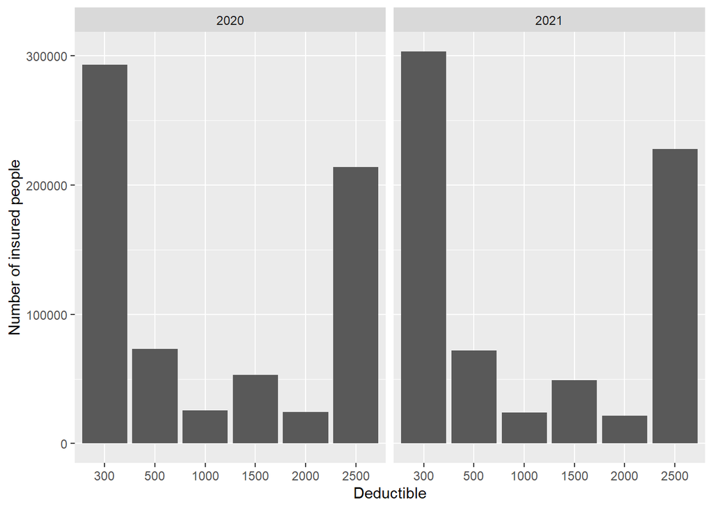

```r
# Since those are real data, check the distribution of franchise. Check for adults
stamm  %>%
  filter(age_group != "0-18")  %>%
  ggplot(aes(x = as.factor(JAHRESFRANCHISE), y = ANZAHL_VERS)) +
  geom_bar(stat = "identity") +
  facet_wrap(JAHR_STA ~. ) +
  labs(y = "Number of insured people",
       x = "Deductible")
```

```r
# stamm  %>%
#   filter(age_group != "0-18")  %>%
#   mutate(ageP = as.numeric(str_sub(age_group, 1, 2)))  %>%
#   group_by(JAHRESFRANCHISE, JAHR_STA)  %>%
#   summarise(meanAge = mean(ageP))  %>%
#   ggplot(aes(x = as.factor(JAHRESFRANCHISE), y = meanAge,
#              color = as.factor(JAHR_STA),
#              group = as.factor(JAHR_STA))) +
#   geom_point() +
#   geom_line() +
#   facet_wrap(JAHR_STA ~. ) +
#   theme_classic() +
#   labs(color = "Year", # not exam-relevant
#        y = "Mean age",
#        x = "Deductible")
```

### 5. Explore the dataset containing medical costs for psychological consultations.

Get some summary statistics about the “medi” dataset. What is the relationship between age and total consultation costs, and gender and consultation costs? What should you pay attention to when working with these data?

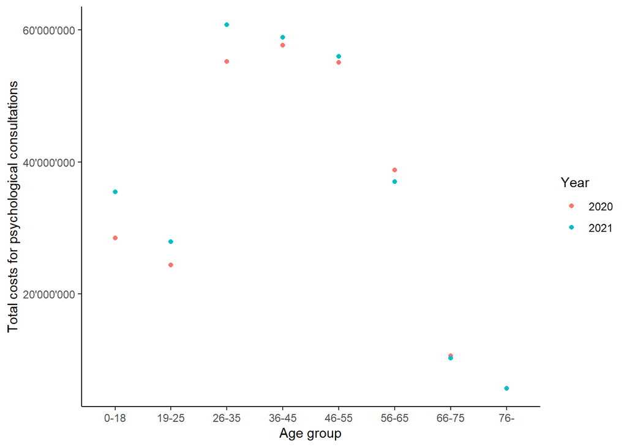

```r
# Relationship between years and costs
konsSummary <- kons |>
  group_by(JAHR, B003_ALTERSGRUPPE) |>
  summarise(min = min(PLE_KOSTEN),
            mean = mean(PLE_KOSTEN),
            max = max(PLE_KOSTEN),
            tot = sum(PLE_KOSTEN))

konsSummary |>
  ggplot(aes(x = B003_ALTERSGRUPPE, y = tot, color = as.factor(JAHR))) +
  geom_point() +
  theme_classic() +
  labs(color = "Year",
       y = "Total costs for psychological consultations",
       x = "Age group") +
  scale_y_continuous(labels = function(x) format(x, big.mark = "'")) # not exam-relevant
```

### 6. What is the most frequent provider of psychological consultations?

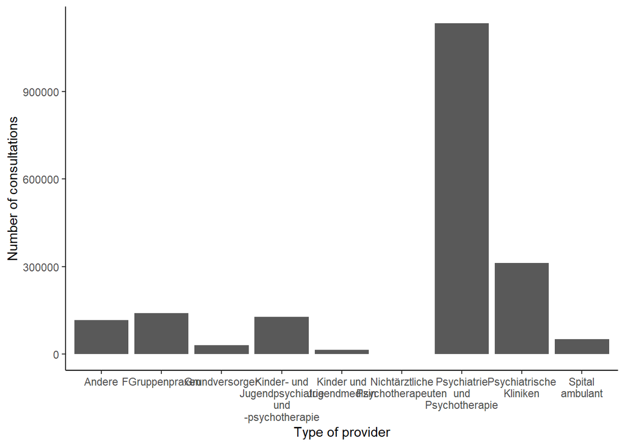

```r
kons$AA_TYPE_graph <- str_wrap(kons$AA_TYPE, 12) # not exam-relevant

kons |>
  filter(JAHR == 2021) |>
  group_by(AA_TYPE_graph) |>
  summarise(Anzahl_Kons = sum(ANZAHL_KONS))  |>
  ggplot(aes(x = AA_TYPE_graph, y = Anzahl_Kons)) +
  geom_bar(stat = "identity") +
  labs(x = "Type of provider",
       y = "Number of consultations") +
  theme_classic()
```

### 7. Now, merge both datasets.

Why is it important to merge them. What kind of merge do you need, and what key are you using? We will now focus only on providers for “Psychiatrie und Psychotherapie”.

```r
kons <- kons |>
    filter(AA_TYPE == "Psychiatrie und Psychotherapie")
```

```r
stamm <- stamm |>
  group_by(JAHR_STA, KANTON, B003_GESCHLECHT_KBEZ, age_group)  %>%
  summarise(ANZAHL_VERS_MONATE = sum(ANZAHL_VERS_MONATE),
            ANZAHL_VERS = sum(ANZAHL_VERS, na.rm = T))


df <- left_join(stamm, kons, by = c("JAHR_STA" = "JAHR",
                                    "KANTON" = "KANTON_PAT",
                                    "B003_GESCHLECHT_KBEZ",
                                    "age_group" = "B003_ALTERSGRUPPE"))
```

### 8. Compute the number of consultations adjusted by the number of months. Give some summary statistics per year.

```r
df <- df  %>%
    mutate(KONS_MONAT = ANZAHL_KONS / ANZAHL_VERS_MONATE)

df  %>%
    group_by(JAHR_STA)  %>%
    summarise(mean(KONS_MONAT, na.rm = T),
              min(KONS_MONAT, na.rm = T),
              max(KONS_MONAT, na.rm = T))
```

```
## # A tibble: 2 × 4
##   JAHR_STA mean(KONS_MONAT, na.r…¹ min(KONS_MONAT, na.r…² max(KONS_MONAT, na.r…³
##      <dbl>                   <dbl>                  <dbl>                  <dbl>
## 1     2020                  0.0566              0                          0.421
## 2     2021                  0.0583              0.0000330                  0.558
## # ℹ abbreviated names: ¹`mean(KONS_MONAT, na.rm = T)`,
## #   ²`min(KONS_MONAT, na.rm = T)`, ³`max(KONS_MONAT, na.rm = T)`
```

### 9. Give some summary stats per age group. Where is the group with the largest increase in number of consultations?

```r
df |>
    group_by(JAHR_STA, age_group) |>
    summarise(meanKonsMonat = mean(KONS_MONAT, na.rm = T),
              minKonsMonat = min(KONS_MONAT, na.rm = T),
              maxKonsMonat = max(KONS_MONAT, na.rm = T))
```

```
## # A tibble: 16 × 5
## # Groups:   JAHR_STA [2]
##    JAHR_STA age_group meanKonsMonat minKonsMonat maxKonsMonat
##       <dbl> <chr>             <dbl>        <dbl>        <dbl>
##  1     2020 0-18            0.0161     0.000867        0.141
##  2     2020 19-25           0.119      0.0160          0.421
##  3     2020 26-35           0.0720     0.0113          0.303
##  4     2020 36-45           0.0789     0.0107          0.335
##  5     2020 46-55           0.0798     0.00779         0.347
##  6     2020 56-65           0.0674     0.00174         0.331
##  7     2020 66-75           0.0272     0.000392        0.119
##  8     2020 76-             0.00938    0               0.0790
##  9     2021 0-18            0.0200     0.00236         0.114
## 10     2021 19-25           0.158      0.0155          0.558
## 11     2021 26-35           0.0833     0.00574         0.335
## 12     2021 36-45           0.0761     0.00580         0.356
## 13     2021 46-55           0.0765     0.00137         0.340
## 14     2021 56-65           0.0597     0.00103         0.322
## 15     2021 66-75           0.0231     0.00114         0.136
## 16     2021 76-             0.00874    0.0000330       0.0910
```

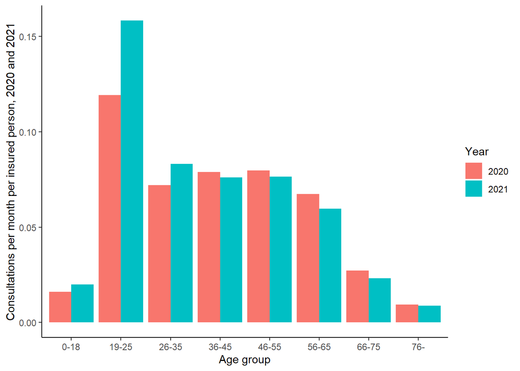

```r
df |>
  group_by(JAHR_STA, age_group) |>
  summarise(mean = mean(KONS_MONAT, na.rm = T)) |>
  ggplot(aes(x = age_group, y = mean, fill = as.factor(JAHR_STA))) +
  geom_bar(stat="identity", position = "dodge") + # not exam-relevant
  theme_classic() +
  labs(y = "Consultations per month per insured person, 2020 and 2021",
       x = "Age group",
       fill = "Year")
```

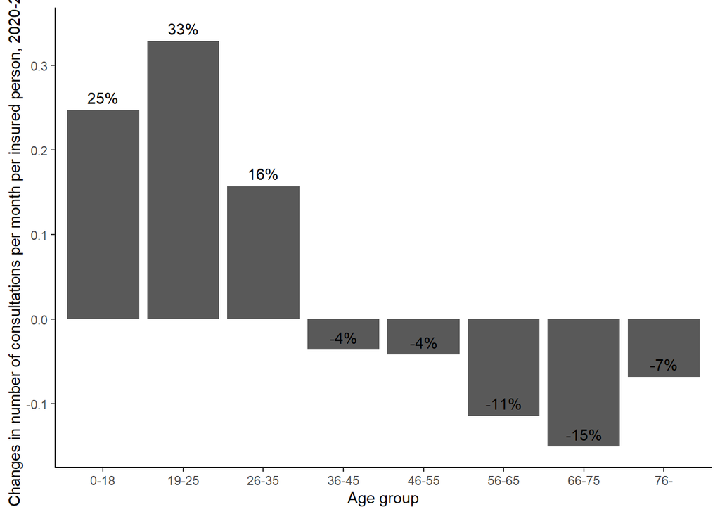

```r
df |>
  group_by(JAHR_STA, age_group) |>
  summarise(mean = mean(KONS_MONAT, na.rm = T)) |>
  pivot_wider(names_from = JAHR_STA, values_from = mean) |>
  mutate(pct = (`2021` - `2020`)/`2020`) |>
  ggplot(aes(x = age_group, y = pct, label = paste0(round(pct, 2)*100, "%"))) +
  geom_bar(stat = "identity")  +
  geom_text(nudge_y = 0.015) + # not exam-relevant
  labs(y = "Changes in number of consultations per month per insured person, 2020-2021",
       x = "Age group") +
  theme_classic()
```

### 10. Does this vary also with gender?

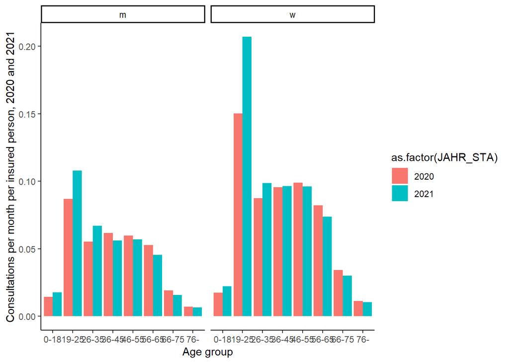

```r
df |>
  group_by(JAHR_STA, age_group, B003_GESCHLECHT_KBEZ) |>
  summarise(mean = mean(KONS_MONAT, na.rm = T)) |>
  ggplot(aes(x = age_group, y = mean, fill = as.factor(JAHR_STA))) +
  geom_bar(stat="identity", position = "dodge") +
  theme_classic() +
  labs(y = "Consultations per month per insured person, 2020 and 2021",
       x = "Age group",
       color = "Year") +
  facet_wrap(B003_GESCHLECHT_KBEZ ~ .)
```

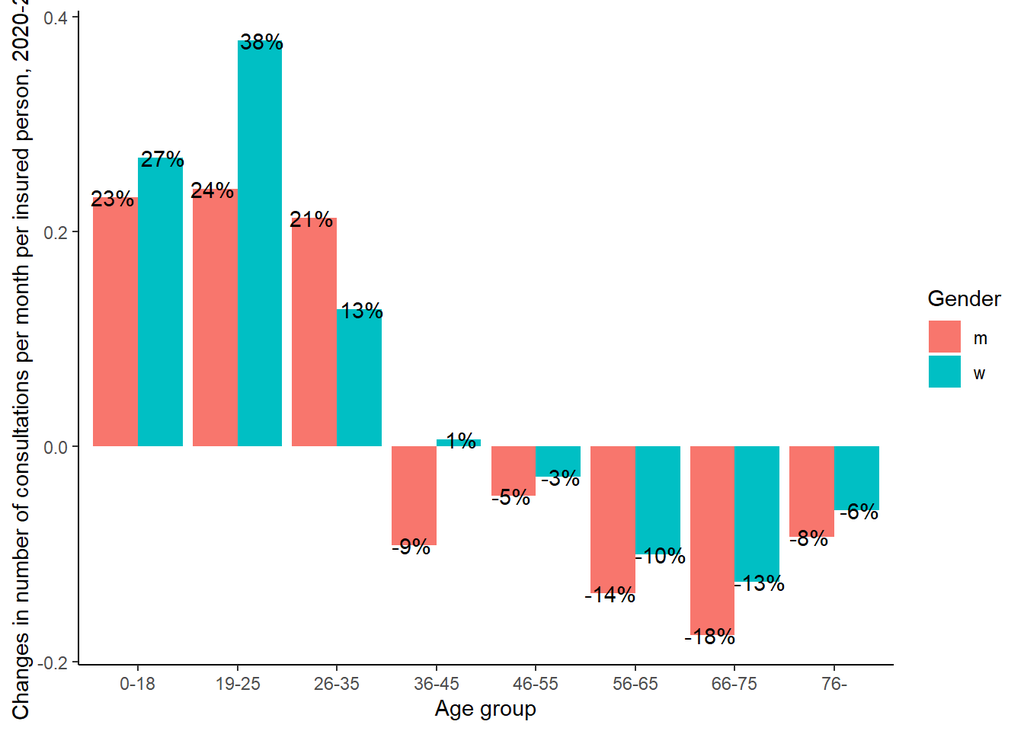

```r
df |>
  group_by(JAHR_STA, age_group, B003_GESCHLECHT_KBEZ) |>
  summarise(mean = mean(KONS_MONAT, na.rm = T)) |>
  pivot_wider(names_from = JAHR_STA, values_from = mean) |>
  mutate(pct = (`2021` - `2020`)/`2020`) |>
  ggplot(aes(x = age_group, y = pct, label = paste0(round(pct, 2)*100, "%"),
             fill = as.factor(B003_GESCHLECHT_KBEZ),
             group = as.factor(B003_GESCHLECHT_KBEZ))) +
  geom_bar(stat = "identity", position = "dodge")  +
  geom_text(aes(group = as.factor(B003_GESCHLECHT_KBEZ)),
            position=position_dodge(width=1)) +
  labs(y = "Changes in number of consultations per month per insured person, 2020-2021",
       x = "Age group",
       fill = "Gender") +
  theme_classic()
```

### 11. What are the costs of young women needing more psychological care?

Estimate the costs for the canton of Zürich

```r
costs <- df |>
  filter(KANTON == "ZH") |>
  mutate(COSTS_MONTH = PLE_KOSTEN/ANZAHL_VERS_MONATE) |>
  group_by(JAHR_STA, age_group, B003_GESCHLECHT_KBEZ) |>
  summarise(mean = mean(COSTS_MONTH, na.rm = T),
            totalcosts = sum(PLE_KOSTEN, na.rm = T)) |>
  pivot_wider(names_from = JAHR_STA, values_from = c(mean, totalcosts))

# Total costs increase
(sum(costs$totalcosts_2021) - sum(costs$totalcosts_2020))
```

```
## [1] 1682155
```

```r
(sum(costs$totalcosts_2021) - sum(costs$totalcosts_2020)) / sum(costs$totalcosts_2020)
```

```
## [1] 0.03144282
```

```r
# Cost increase for young women
costswy <- costs |>
  filter(age_group == "19-25" & B003_GESCHLECHT_KBEZ == "w")
costswy$totalcosts_2021 - costswy$totalcosts_2020
```

```
## [1] 663500.1
```

```r
(costswy$totalcosts_2021 - costswy$totalcosts_2020) / (costswy$totalcosts_2020)
```

```
## [1] 0.2455422
```